# R Notebook

## Answering the first question

### A simple Kaplan-Meier analysis

1- For the countries in the sample if the moving average of the number of cases in the previous 7 days during the first 4 months after the pandemic started (i.e. April 1st 2020 till July 31 2020), reaches a maximum value, how long does it take so this value drops by 50%? Canada performance was not better than 55% of countries that could reduce the number of daily cases by 50%.

78 country could reduce the maximum number of cases bt 50%.

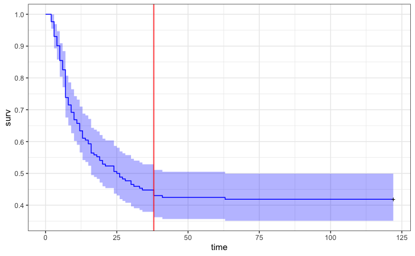

```r
autoplot(surv1,surv.colour = "blue",surv.geom = "step") +
  geom_vline(xintercept = 38,color="red") +
  scale_y_continuous(n.breaks = 10) +
  theme_bw()
```

## Countries characteristics and their performance in reducing the number of cases during the first 4 months afte the begning of the pandemic.

| country | n |
| --- | --- |
| Afghanistan | 11 |
| Albania | 11 |
| Algeria | 11 |
| Andorra | 11 |
| Angola | 11 |
| Antigua and Barbuda | 11 |
| Argentina | 11 |
| Armenia | 11 |
| Australia | 11 |
| Austria | 11 |

[output cut: 155 more lines]

## select the varaibles of intersts

Here only a few variables are selected for the sake of illustration. The data is filtered for after 2010 and then it was averaged across the years after 2010.

| country | current_health_expenditure_percent_of_gdp | gdp_per_capita_constant_2010_us | gdp_constant_2010_us | age_dependency_ratio_percent_of_working_age_population | population_total | urban_population | percent_urban |
| --- | --- | --- | --- | --- | --- | --- | --- |
| Afghanistan | 9.629279 | 570.0827 | 19535637416 | 90.69137 | 34247382.56 | 8515414.33 | 0.2482111 |
| Albania | 5.103167 | 4620.3573 | 13311993223 | 46.23040 | 2882291.11 | 1652666.44 | 0.5735256 |
| Algeria | 6.254500 | 4698.0329 | 187055474291 | 53.36912 | 39784362.22 | 28197162.11 | 0.7079167 |
| Andorra | 6.268195 | 42524.4937 | 3362670320 | NaN | 79179.78 | 69958.56 | 0.8834714 |
| Angola | 2.608471 | 3555.7906 | 98867912903 | 97.27336 | 27940535.67 | 17760762.44 | 0.6340600 |
| Antigua and Barbuda | 5.388455 | 13713.5265 | 1283425353 | 44.90282 | 93407.00 | 23385.11 | 0.2504648 |
| Argentina | 9.751320 | 10415.0647 | 448713219677 | 56.16546 | 43118617.22 | 39456266.89 | 0.9149744 |
| Armenia | 9.933731 | 3964.1543 | 11588698489 | 45.10327 | 2920752.11 | 1844909.33 | 0.6316600 |
| Australia | 9.003549 | 55104.9843 | 1315519261787 | 51.17044 | 23848117.89 | 20441637.33 | 0.8570522 |
| Austria | 10.288385 | 48624.7494 | 420154453168 | 49.19255 | 8638037.11 | 4988319.67 | 0.5773889 |

[output cut: 155 more lines]

## join the WDI data with data_surv1 and other cleanings.

| country | current_health_expenditure_percent_of_gdp | gdp_per_capita_constant_2010_us | gdp_constant_2010_us | age_dependency_ratio_percent_of_working_age_population | population_total | urban_population | percent_urban | time_passed | event | percent_urban_cat | gdp_per_capita_constant_2010_us_cat | current_health_expenditure_percent_of_gdp_cat | population_total_cat |
| --- | --- | --- | --- | --- | --- | --- | --- | --- | --- | --- | --- | --- | --- |
| Bangladesh | 2.441404 | 1025.472 | 160841561405 | 52.41024 | 156207371 | 53685457.9 | 0.3431122 | 122 | 0 | [0.131,0.565] | [1.03e+03,4.61e+03] | [2.37,6.4] | (2.79e+07,1.37e+09] |
| Cambodia | 6.604493 | 1034.339 | 16139241384 | 56.14128 | 15517355 | 3452218.1 | 0.2220633 | 122 | 0 | [0.131,0.565] | [1.03e+03,4.61e+03] | (6.4,16.6] | (6.32e+06,2.79e+07] |
| Pakistan | 2.709386 | 1091.018 | 218598971315 | 67.70640 | 199658121 | 72005744.2 | 0.3603522 | 15 | 1 | [0.131,0.565] | [1.03e+03,4.61e+03] | [2.37,6.4] | (2.79e+07,1.37e+09] |
| Kenya | 5.346094 | 1099.380 | 52883938058 | 77.01028 | 47873335 | 12333933.0 | 0.2569133 | 122 | 0 | [0.131,0.565] | [1.03e+03,4.61e+03] | [2.37,6.4] | (2.79e+07,1.37e+09] |
| Benin | 2.857151 | 1137.800 | 12107487481 | 86.12202 | 10598992 | 4855357.3 | 0.4571178 | 5 | 1 | [0.131,0.565] | [1.03e+03,4.61e+03] | [2.37,6.4] | (6.32e+06,2.79e+07] |
| Zimbabwe | 6.990944 | 1217.630 | 16810951427 | 82.62297 | 13790304 | 4477945.6 | 0.3248267 | 122 | 0 | [0.131,0.565] | [1.03e+03,4.61e+03] | (6.4,16.6] | (6.32e+06,2.79e+07] |
| Haiti | 8.472483 | 1251.323 | 13382079643 | 64.21877 | 10689451 | 5609585.3 | 0.5239022 | 20 | 1 | [0.131,0.565] | [1.03e+03,4.61e+03] | (6.4,16.6] | (6.32e+06,2.79e+07] |
| Burma | 4.057177 | 1327.918 | 70041319858 | 49.48706 | 52599991 | 15735379.3 | 0.2990456 | 7 | 1 | [0.131,0.565] | [1.03e+03,4.61e+03] | [2.37,6.4] | (2.79e+07,1.37e+09] |
| Senegal | 4.235118 | 1403.154 | 20623386764 | 86.70843 | 14615005 | 6718255.7 | 0.4588767 | 122 | 0 | [0.131,0.565] | [1.03e+03,4.61e+03] | [2.37,6.4] | (6.32e+06,2.79e+07] |
| Cameroon | 3.790791 | 1422.712 | 33319051480 | 84.83448 | 23337153 | 12760701.3 | 0.5457311 | 6 | 1 | [0.131,0.565] | [1.03e+03,4.61e+03] | [2.37,6.4] | (6.32e+06,2.79e+07] |

[output cut: 110 more lines]

## The role of population

three categories of population were generated. The log-rank test’s null hypothesis is not rejected even at 10% (H0: no differecnes exists in survival between the two groups)

### simple analysis

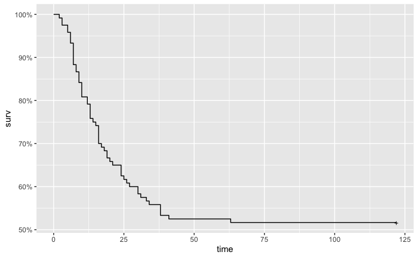

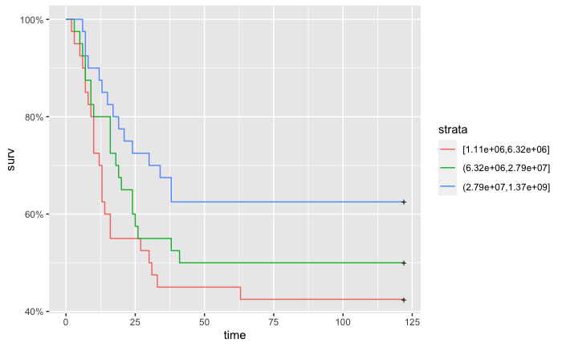

## The role of gdp per capita

three categories of GDP per capita were generated. The log-rank test’s null hypothesis is rejected at 1% (H0: no differences exists in survival between the two groups). countries with GDP per capita of above $ 14500 could reduce the number of cases by 50% and more signficantly sooner than countries with lower income.

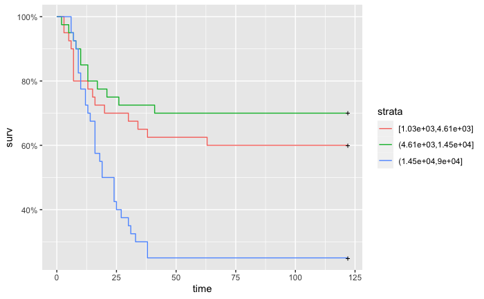

# Cox model with GDP per capita

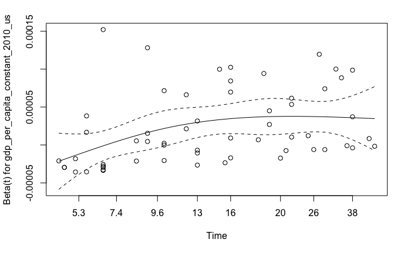

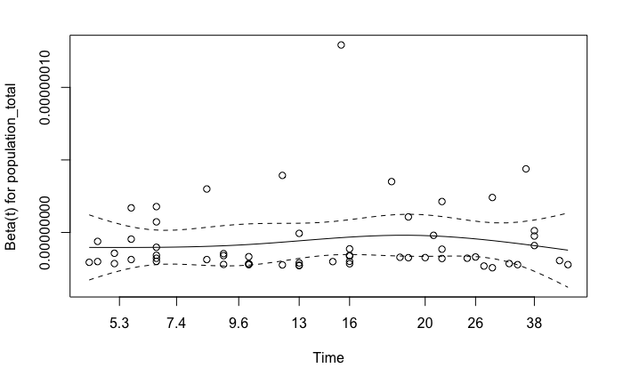